# Tree-Based Methods

Team 4: Driss Baraket, Yanjie Long, Garrett deFisser, Emma Harrison

2/24/2021

### Preliminaries

In this lab, we will be discussing decision trees as a supervised learning algorithm that can be used in both regression and classification problems. It is also worth mentioning that the trees work both categorical and continuous input and output variables.

Here is what a basic decision tree looks like:

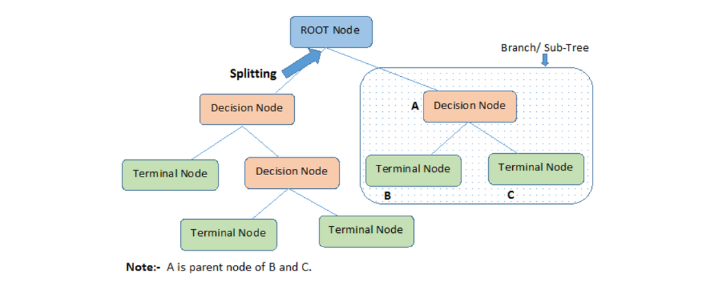

What problem are we trying to solve Here?

1. Tree-based methods: involve stratifying or segmenting the predictor space into a number of simple regions.
2. Tree-based methods are simple and useful for interpretation; however, they typically are not competitive with the best supervised learning approaches, so we use bagging, random forests, and boosting to create multiple trees to improve results.
3. A regression tree is built through a process that splits the data into partitions or branches, and then continues splitting each partition into smaller groups as the method moves up each branch.
4. A classification tree is very similar to a regression tree, except that it is used to predict a qualitative response rather than a quantitative one.
5. Bagging- a general purpose procedure for reducing the variance of a statistical learning method. Creates multiple copies of the original training data set using the bootstrapping method, fits a separate decision tree to each copy, and then combines all of the trees in order to create a single predictive model.
6. Random forests- provide an improvement over bagged trees by way of a random small tweak that decorrelates the trees.
7. Boosting- similar to bagging, but the trees are grown sequentially: each tree is grown using information from previously grown trees. Boosting does not involve bootstrap sampling; instead each tree is fit on a modified version of the original data set.

Our focus is going to be on these two decision tree models:

1. Fitting Classification Trees - used to predict a qualitative response.
2. Fitting Regression Trees - similar to the classification tree, but it predicts a quantitative response.

#### Dataset

We will be using the “Carseats” (part of the ISLR package) and the “Boston” datasets:

1. Carseats represents the Sales Of Child Car Seats: it is a simulated data set(with 400 observations & 11 variables) containing sales of child car seats at 400 different stores.
   1. The X’s in this dataset are (Sales, CompPrice, Income, Advertising, Population, Price, ShelveLoc, Age, Education, Urban, US)
   2. The Y in our discussion is High - categorical
2. Boston is derived from information collected by the U.S. Census Service concerning housing in the area of Boston Area. it has (506 observations and 14 variables).
   1. The X’s in this dataset are (crim, zn, indus, chas, nox, rm, age, dis, rad, tax, ptratio, black, lstat)
   2. The Y is medv

For the purpose of this exercise, we did not have to transform any of the existing variables.

### Fitting Classification Trees

Before loading in any libraries, you must ensure that the tree and MASS packages are installed. Begin by loading in the tree and ISLR packages as well as attaching the Carseats package.

Next, Carseats is merged with High in a dataframe.

```r
library(ISLR)
attach(Carseats)
library(tree)
High = as.factor(ifelse(Sales >=8,"Yes", "No"))
Carseats= data.frame(Carseats, High)
```

The tree function is then used to fit a classification tree in order to predict High using all of the variables but Sales.

Next, take a summary of the classification tree. The summary shows that the variables used in the tree are: “ShelveLoc”, “Price”, “Income”, “Comp Price”, “Population”, “Age”, “US”, and “Advertising”. There are 27 terminal nodes, and the training error rate is 9%. A small deviance indicates that the tree provides a good fit to the data.

```r
tree.carseats= tree(High~.-Sales,Carseats)
summary(tree.carseats )
```

```
##
## Classification tree:
## tree(formula = High ~ . - Sales, data = Carseats)
## Variables actually used in tree construction:
## [1] "ShelveLoc"   "Price"       "Income"      "CompPrice"   "Population"
## [6] "Advertising" "Age"         "US"
## Number of terminal nodes:  27
## Residual mean deviance:  0.4575 = 170.7 / 373
## Misclassification error rate: 0.09 = 36 / 400
```

The plot function is used to display the tree and the text function is used to display the node labels. Pretty=0 instructs R to include the full category names for each qualitative variable. The results show that the most important indicator of sales is shelving location.

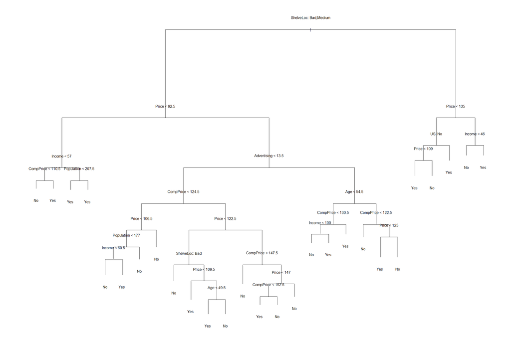

```r
plot(tree.carseats )
text(tree.carseats ,pretty =0)
```

```r
tree.carseats
set.seed(2)
```

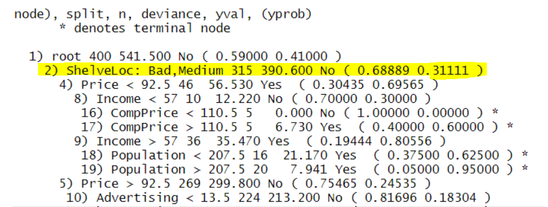

In order to accurately evaluate a classification tree, you must estimate the testing error, not the training error. To do this- the observations are split into a testing and a training set. The predict function is used and type=”class” is used to return the actual class prediction. This approach leads to correct predictions for around 77% of locations in the test data set.

Disclaimer: some of the results from the confusion matrix changed compared to the book due to package updates in R!

```r
set.seed(2)

train=sample (1: nrow(Carseats), 200)
Carseats.test= Carseats [-train,]
High.test=High[-train]
tree.carseats =tree(High~.-Sales , Carseats ,subset=train)
tree.pred=predict(tree.carseats ,Carseats.test ,type="class")
table(tree.pred ,High.test)
```

```
##          High.test
## tree.pred  No Yes
##       No  104  33
##       Yes  13  50
```

```r
(104+50)/200
```

```
## [1] 0.77
```

The next step is to determine whether pruning will lead to improved results using the cv.tree function, which performs cross-validation to determine the optimal level of tree complexity. FUN=prune.misclass is used to tell the function that we want the classification error rate, instead of the deviance, to guide the cross-validation and pruning processes.

The cv.tree function returns size, deviation, k, and method. Size is the number of terminal nodes for each tree, dev is the cross-validation error rate, and k is the value of the parameter used. The results show that the tree with 21 terminal nodes returns the lowest error with its cross-validation error of 74.

```r
set.seed(3)
cv.carseats =cv.tree(tree.carseats ,FUN=prune.misclass )
names(cv.carseats )
```

```
## [1] "size"   "dev"    "k"      "method"
```

```r
cv.carseats
```

```
## $size
## [1] 21 19 14  9  8  5  3  2  1
##
## $dev
## [1] 74 76 81 81 75 77 78 85 81
##
## $k
## [1] -Inf  0.0  1.0  1.4  2.0  3.0  4.0  9.0 18.0
##
## $method
## [1] "misclass"
##
## attr(,"class")
## [1] "prune"         "tree.sequence"
```

The error rate is plotted as a function of both size and k.

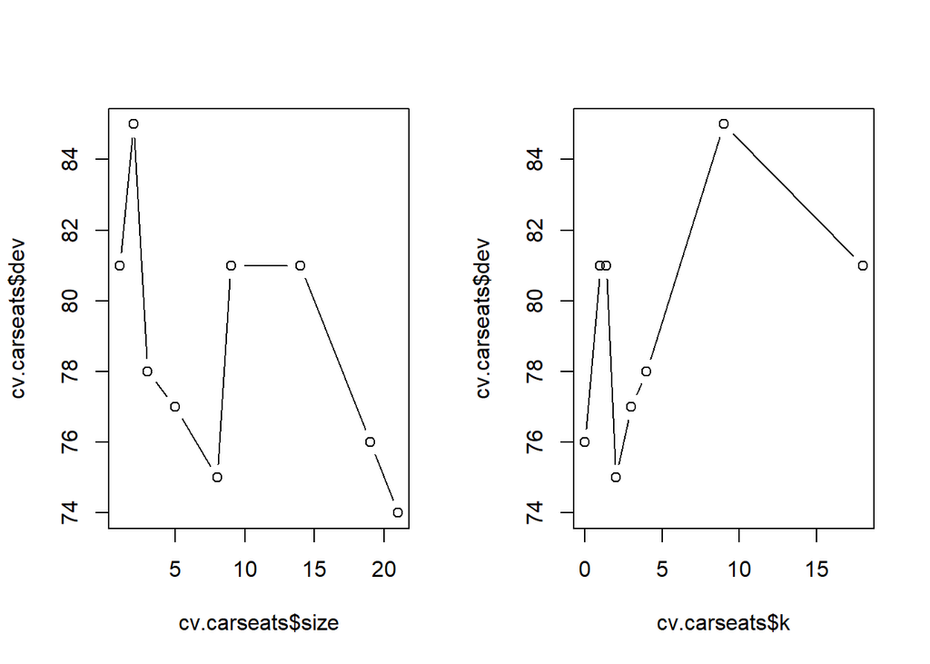

```r
set.seed(3)
par(mfrow=c(1,2))
plot(cv.carseats$size ,cv.carseats$dev ,type="b")
plot(cv.carseats$k ,cv.carseats$dev ,type="b")
```

The prune.misclass() function is applied in order to prune the tree to obtain the 21-node tree and then it is plotted.

```r
par(mfrow=c(1,1))
set.seed(3)
prune.carseats =prune.misclass (tree.carseats ,best=21)
```

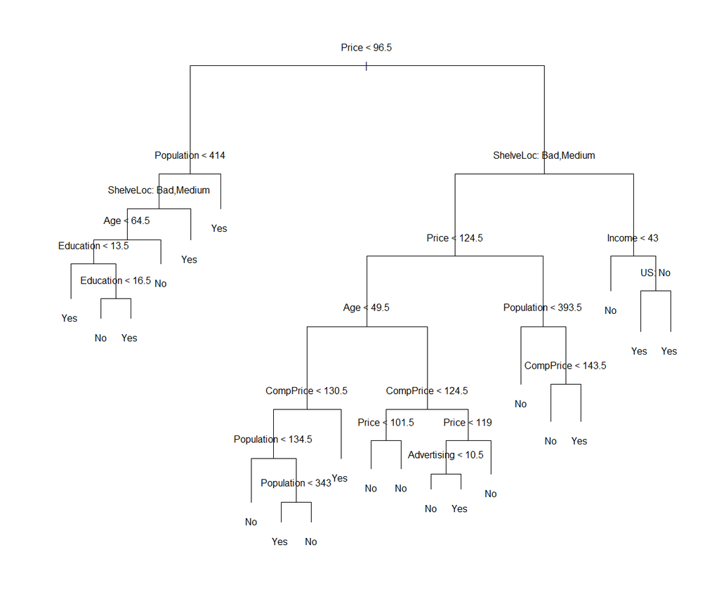

```r
plot(prune.carseats )
text(prune.carseats ,pretty =0)
```

```r
tree.pred=predict(prune.carseats ,Carseats.test , type="class")
table(tree.pred ,High.test)
```

```
##          High.test
## tree.pred  No Yes
##       No  103  31
##       Yes  14  52
```

```r
(103+52) /200
```

```
## [1] 0.775
```

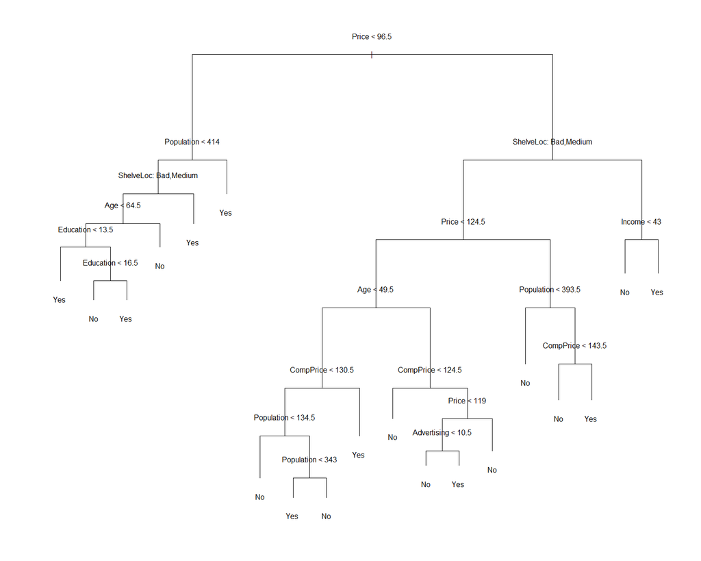

```r
prune.carseats =prune.misclass (tree.carseats ,best=15)
plot(prune.carseats )
text(prune.carseats ,pretty =0)
```

Out of all of these methods, the pruning process results in the highest classification accuracy with its rate of 77.5%.

```r
tree.pred=predict(prune.carseats ,Carseats.test , type="class")
table(tree.pred ,High.test)
```

```
##          High.test
## tree.pred  No Yes
##       No  103  31
##       Yes  14  52
```

```r
(103+52) /200
```

```
## [1] 0.775
```

As a result, the pruning method did yield a better result, but in this case, the accuracy rate increase by just 0.5%